# AI & Fairness: Bias Mitigation

### 1 Objective:

Objective of this project is to mitigate bias in the Student Perfromance dataset and compare the fairness metrics on original and debiased datasets. First step is to remove the bias in the dataset and then use debiased dataset in downstream machine learning algorithms so that results of the algorithms preserve fairness.

The idea is that we want to learn a new representation Z such that it removes the information correlated to the sensitive attribute A and preserves the information of X as much as possible.[1]

```python
import pandas as pd
import numpy as np
import time
import matplotlib.pyplot as plt
import seaborn as sns
from tqdm import tqdm

from sklearn.model_selection import train_test_split
from sklearn.preprocessing import LabelEncoder
from sklearn.compose import make_column_transformer
from sklearn.preprocessing import RobustScaler
from sklearn.preprocessing import OneHotEncoder
from sklearn.preprocessing import StandardScaler
from sklearn.linear_model import LogisticRegression

from aif360.metrics import BinaryLabelDatasetMetric
from aif360.datasets import BinaryLabelDataset
from IPython.display import Markdown, display
from aif360.algorithms.preprocessing.reweighing import Reweighing
from aif360.algorithms.preprocessing import DisparateImpactRemover
from aif360.metrics import ClassificationMetric
from common_utils import compute_metrics
```

### 2 Data Analysis & Data Preparation

#### 2.1 Dataset

This dataset consists of data on student's achievement in secondary education of two Portuguese schools. The data attributes include student grades, demographic, social and school related features and it was collected by using school reports and questionnaires. Two datasets are provided regarding the performance in two distinct subjects: Mathematics (mat) and Portuguese language (por). These two datasets were modeled under binary/five-level classification and regression tasks. The target attribute G3 has a strong correlation with attributes G2 and G1. This occurs because G3 is the final year grade (issued at the 3rd period), while G1 and G2 correspond to the 1st and 2nd period grades. It is more difficult to predict G3 without G2 and G1, but such prediction is much more useful. For this project dataset for Portuguese language is used. [2] Dataset can be found at http://archive.ics.uci.edu/ml/datasets/Student+Performance

**Depended Variables**

**Legally Recognized Protected Class and corresponding Legal Precedence/Law**

- sex - student's sex (Equal Pay Act of 1963; Civil Rights Act of 1964, 1991)
- age - student's age (Age Discrimination in Employment Act of 1967)
- Pstatus - parent's cohabitation status (Civil Rights Act of 1968)

#### 2.2 Describe Dataset

```python
#load dataset and print shape
dataset_loc = "./student/student-por.csv"
df = pd.read_csv(dataset_loc, sep=";")
print('Dataset consists of {} Observations and {} Variables'.format(df.shape[0],df.shape[1]))
```

```
Dataset consists of 649 Observations and 33 Variables
```

```python
# dataset summary
df.head()
```

|  | school | sex | age | address | famsize | Pstatus | Medu | Fedu | Mjob | Fjob | ... | famrel | freetime | goout | Dalc | Walc | health | absences | G1 | G2 | G3 |
| --- | --- | --- | --- | --- | --- | --- | --- | --- | --- | --- | --- | --- | --- | --- | --- | --- | --- | --- | --- | --- | --- |
| 0 | GP | F | 18 | U | GT3 | A | 4 | 4 | at_home | teacher | ... | 4 | 3 | 4 | 1 | 1 | 3 | 4 | 0 | 11 | 11 |
| 1 | GP | F | 17 | U | GT3 | T | 1 | 1 | at_home | other | ... | 5 | 3 | 3 | 1 | 1 | 3 | 2 | 9 | 11 | 11 |
| 2 | GP | F | 15 | U | LE3 | T | 1 | 1 | at_home | other | ... | 4 | 3 | 2 | 2 | 3 | 3 | 6 | 12 | 13 | 12 |
| 3 | GP | F | 15 | U | GT3 | T | 4 | 2 | health | services | ... | 3 | 2 | 2 | 1 | 1 | 5 | 0 | 14 | 14 | 14 |
| 4 | GP | F | 16 | U | GT3 | T | 3 | 3 | other | other | ... | 4 | 3 | 2 | 1 | 2 | 5 | 0 | 11 | 13 | 13 |

5 rows × 33 columns

```python
# dataset columns and data types
df.dtypes
```

```
school        object
sex           object
age            int64
address       object
famsize       object
Pstatus       object
Medu           int64
Fedu           int64
Mjob          object
Fjob          object
reason        object
guardian      object
traveltime     int64
studytime      int64
failures       int64
schoolsup     object
famsup        object
paid          object
activities    object
nursery       object
higher        object
internet      object
romantic      object
famrel         int64
freetime       int64
goout          int64
Dalc           int64
Walc           int64
health         int64
absences       int64
G1             int64
G2             int64
G3             int64
dtype: object
```

```python
#describe dataset
df.describe()
```

|  | age | Medu | Fedu | traveltime | studytime | failures | famrel | freetime | goout | Dalc | Walc | health | absences | G1 | G2 | G3 |
| --- | --- | --- | --- | --- | --- | --- | --- | --- | --- | --- | --- | --- | --- | --- | --- | --- |
| count | 649.000000 | 649.000000 | 649.000000 | 649.000000 | 649.000000 | 649.000000 | 649.000000 | 649.000000 | 649.000000 | 649.000000 | 649.000000 | 649.000000 | 649.000000 | 649.000000 | 649.000000 | 649.000000 |
| mean | 16.744222 | 2.514638 | 2.306626 | 1.568567 | 1.930663 | 0.221880 | 3.930663 | 3.180277 | 3.184900 | 1.502311 | 2.280431 | 3.536210 | 3.659476 | 11.399076 | 11.570108 | 11.906009 |
| std | 1.218138 | 1.134552 | 1.099931 | 0.748660 | 0.829510 | 0.593235 | 0.955717 | 1.051093 | 1.175766 | 0.924834 | 1.284380 | 1.446259 | 4.640759 | 2.745265 | 2.913639 | 3.230656 |
| min | 15.000000 | 0.000000 | 0.000000 | 1.000000 | 1.000000 | 0.000000 | 1.000000 | 1.000000 | 1.000000 | 1.000000 | 1.000000 | 1.000000 | 0.000000 | 0.000000 | 0.000000 | 0.000000 |
| 25% | 16.000000 | 2.000000 | 1.000000 | 1.000000 | 1.000000 | 0.000000 | 4.000000 | 3.000000 | 2.000000 | 1.000000 | 1.000000 | 2.000000 | 0.000000 | 10.000000 | 10.000000 | 10.000000 |
| 50% | 17.000000 | 2.000000 | 2.000000 | 1.000000 | 2.000000 | 0.000000 | 4.000000 | 3.000000 | 3.000000 | 1.000000 | 2.000000 | 4.000000 | 2.000000 | 11.000000 | 11.000000 | 12.000000 |
| 75% | 18.000000 | 4.000000 | 3.000000 | 2.000000 | 2.000000 | 0.000000 | 5.000000 | 4.000000 | 4.000000 | 2.000000 | 3.000000 | 5.000000 | 6.000000 | 13.000000 | 13.000000 | 14.000000 |
| max | 22.000000 | 4.000000 | 4.000000 | 4.000000 | 4.000000 | 3.000000 | 5.000000 | 5.000000 | 5.000000 | 5.000000 | 5.000000 | 5.000000 | 32.000000 | 19.000000 | 19.000000 | 19.000000 |

##### 2.3 Data Cleaning

```python
#Find missing values
df.isnull().sum()
```

```
school        0
sex           0
age           0
address       0
famsize       0
Pstatus       0
Medu          0
Fedu          0
Mjob          0
Fjob          0
reason        0
guardian      0
traveltime    0
studytime     0
failures      0
schoolsup     0
famsup        0
paid          0
activities    0
nursery       0
higher        0
internet      0
romantic      0
famrel        0
freetime      0
goout         0
Dalc          0
Walc          0
health        0
absences      0
G1            0
G2            0
G3            0
dtype: int64
```

This dataset has no missing values.

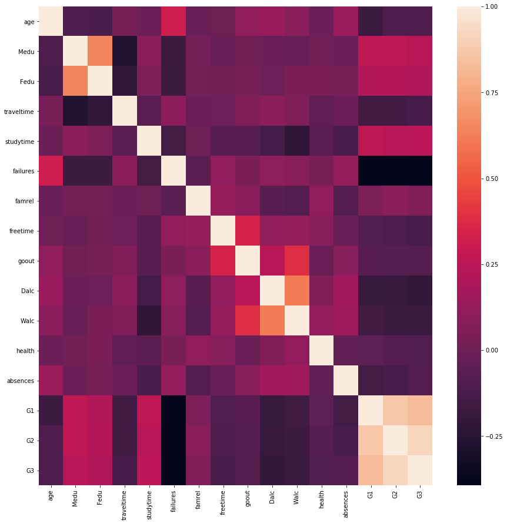

```python
# Find collrealtion among dataset attributes
plt.figure(figsize =(15,15))
sns.heatmap(df.corr(),xticklabels=df.corr().columns,yticklabels=df.corr().columns)
```

Arrtibutes G1 and G2 are highly corellated with each other as well as with dependent variable G3. G1 and G2 are dropped from the dataset.

```python
df.drop(['G1', 'G2'], inplace=True, axis=1)
```

```python
features = ['school', 'sex', 'age', 'address', 'famsize', 'Pstatus', 'Medu', 'Fedu',
       'Mjob', 'Fjob', 'reason', 'guardian', 'traveltime', 'studytime',
       'failures', 'schoolsup', 'famsup', 'paid', 'activities', 'nursery',
       'higher', 'internet', 'romantic', 'famrel', 'freetime', 'goout', 'Dalc',
       'Walc', 'health']
labels = ['absences', 'G3']
```

##### 2.4 Protected Class Attribute

```python
print('Unique values for protected class attribute \'sex\': ',df['sex'].unique())
print('Unique values for protected class attribute \'Pstatus\': ',df['Pstatus'].unique())
print('Unique values for protected class attribute \'age\': ',df['age'].unique())
```

```
Unique values for protected class attribute 'sex':  ['F' 'M']
Unique values for protected class attribute 'Pstatus':  ['A' 'T']
Unique values for protected class attribute 'age':  [18 17 15 16 19 22 20 21]
```

Protected attributes 'Sex' and 'Pstatus' has only two categories. Protected attribute 'Age' is categorized into "Teen" is age is < 18 years and "Adult" if age is >= 18. All portected class attributes are converted to binary attributes.

```python
df['sex'] = df['sex'].map( {'F':0, 'M':1})
df['Pstatus'] = df['Pstatus'].map( {'A':0, 'T':1})
df['age'].values[df['age'] < 18] = 0
df['age'].values[df['age'] >= 18] = 1
```

```python
df
```

|  | school | sex | age | address | famsize | Pstatus | Medu | Fedu | Mjob | Fjob | ... | internet | romantic | famrel | freetime | goout | Dalc | Walc | health | absences | G3 |
| --- | --- | --- | --- | --- | --- | --- | --- | --- | --- | --- | --- | --- | --- | --- | --- | --- | --- | --- | --- | --- | --- |
| 0 | GP | 0 | 1 | U | GT3 | 0 | 4 | 4 | at_home | teacher | ... | no | no | 4 | 3 | 4 | 1 | 1 | 3 | 4 | 11 |
| 1 | GP | 0 | 0 | U | GT3 | 1 | 1 | 1 | at_home | other | ... | yes | no | 5 | 3 | 3 | 1 | 1 | 3 | 2 | 11 |
| 2 | GP | 0 | 0 | U | LE3 | 1 | 1 | 1 | at_home | other | ... | yes | no | 4 | 3 | 2 | 2 | 3 | 3 | 6 | 12 |
| 3 | GP | 0 | 0 | U | GT3 | 1 | 4 | 2 | health | services | ... | yes | yes | 3 | 2 | 2 | 1 | 1 | 5 | 0 | 14 |
| 4 | GP | 0 | 0 | U | GT3 | 1 | 3 | 3 | other | other | ... | no | no | 4 | 3 | 2 | 1 | 2 | 5 | 0 | 13 |
| ... | ... | ... | ... | ... | ... | ... | ... | ... | ... | ... | ... | ... | ... | ... | ... | ... | ... | ... | ... | ... | ... |
| 644 | MS | 0 | 1 | R | GT3 | 1 | 2 | 3 | services | other | ... | yes | no | 5 | 4 | 2 | 1 | 2 | 5 | 4 | 10 |
| 645 | MS | 0 | 1 | U | LE3 | 1 | 3 | 1 | teacher | services | ... | yes | no | 4 | 3 | 4 | 1 | 1 | 1 | 4 | 16 |
| 646 | MS | 0 | 1 | U | GT3 | 1 | 1 | 1 | other | other | ... | no | no | 1 | 1 | 1 | 1 | 1 | 5 | 6 | 9 |
| 647 | MS | 1 | 0 | U | LE3 | 1 | 3 | 1 | services | services | ... | yes | no | 2 | 4 | 5 | 3 | 4 | 2 | 6 | 10 |
| 648 | MS | 1 | 1 | R | LE3 | 1 | 3 | 2 | services | other | ... | yes | no | 4 | 4 | 1 | 3 | 4 | 5 | 4 | 11 |

649 rows × 31 columns

```python
print('Count of protected class member "Female" for category "Sex": ',df[df['sex']==0].shape[0])
print('Count of protected class member "Male" for category "Sex": ',df[df['sex']==1].shape[0])
print('Count of protected class member "Apart" for category "Pstatus": ',df[df['Pstatus']==0].shape[0])
print('Count of protected class member "Together" for category "Pstatus": ',df[df['Pstatus']==1].shape[0])
print('Count of protected class member "Teen" for category "Age": ',df[df['age']==0].shape[0])
print('Count of protected class member "Adult" for category "Age": ',df[df['age']==1].shape[0])
```

```
Count of protected class member "Female" for category "Sex":  383
Count of protected class member "Male" for category "Sex":  266
Count of protected class member "Apart" for category "Pstatus":  80
Count of protected class member "Together" for category "Pstatus":  569
Count of protected class member "Teen" for category "Age":  468
Count of protected class member "Adult" for category "Age":  181
```

##### 2.5 Discretize Dependent Variables

To predict whether student is a high performer, dependent variable G3 is converted to binary attribute. If student's score is between 12 and 20 then student is marked as "Above Average Performer" and represented as 1. If the student perfromance is below 12 (0-11), then student is marked as "Below Average Performer" and represented as 0.

To predict student with high attendence, dependent variable "absences" is also converted to binary. If student has absences between 0 and 4, then student is marked "Focused" and marked as 1. If the student's absence is more than 4, then student is marked as "Unfocused" and represented as 0.

```python
df['G3'].values[df['G3'] < 12] = 0
df['G3'].values[df['G3'] >= 12] = 1
df['G3'].unique()
```

```
array([0, 1], dtype=int64)
```

```python
df['absences'].values[df['absences'] <= 4] = 1
df['absences'].values[df['absences'] > 4] = 0
df['absences'].unique()
```

```
array([1, 0], dtype=int64)
```

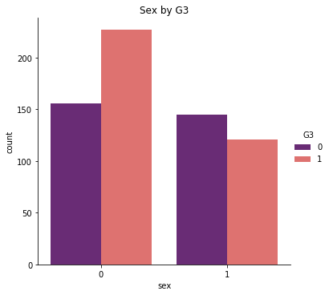

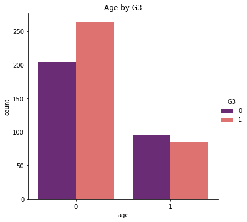

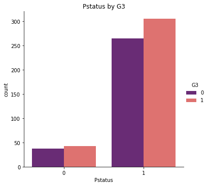

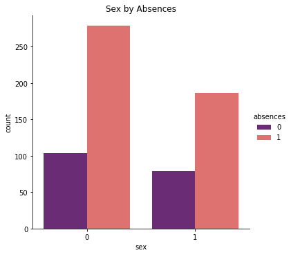

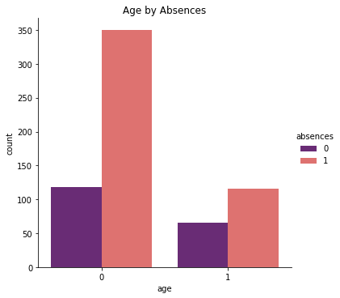

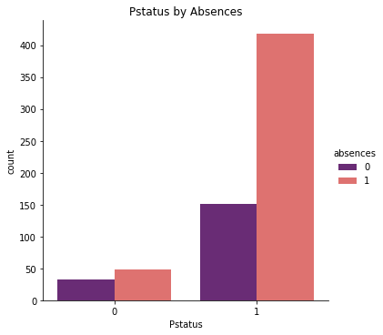

```python
chart = sns.catplot(x="sex", hue="G3", kind="count", palette="magma", data=df).set(title='Sex by G3')
chart = sns.catplot(x="age", hue="G3", kind="count", palette="magma", data=df).set(title='Age by G3')
chart = sns.catplot(x="Pstatus", hue="G3", kind="count", palette="magma", data=df).set(title='Pstatus by G3')
chart = sns.catplot(x="sex", hue="absences", kind="count", palette="magma", data=df).set(title='Sex by Absences')
chart = sns.catplot(x="age", hue="absences", kind="count", palette="magma", data=df).set(title='Age by Absences')
chart = sns.catplot(x="Pstatus", hue="absences", kind="count", palette="magma", data=df).set(title='Pstatus by Absences')
```

##### 2.6 Encode Other Categorical Variables

```python
numvar = [key for key in dict(df.dtypes)
                   if dict(df.dtypes)[key]
                       in ['float64','float32','int32','int64']] # Numeric Variable

catvar = [key for key in dict(df.dtypes)
             if dict(df.dtypes)[key] in ['object'] ] # Categorical Varible
```

```python
for cat in catvar:
    df[cat] = LabelEncoder().fit_transform(df[cat])
df
```

|  | school | sex | age | address | famsize | Pstatus | Medu | Fedu | Mjob | Fjob | ... | internet | romantic | famrel | freetime | goout | Dalc | Walc | health | absences | G3 |
| --- | --- | --- | --- | --- | --- | --- | --- | --- | --- | --- | --- | --- | --- | --- | --- | --- | --- | --- | --- | --- | --- |
| 0 | 0 | 0 | 1 | 1 | 0 | 0 | 4 | 4 | 0 | 4 | ... | 0 | 0 | 4 | 3 | 4 | 1 | 1 | 3 | 1 | 0 |
| 1 | 0 | 0 | 0 | 1 | 0 | 1 | 1 | 1 | 0 | 2 | ... | 1 | 0 | 5 | 3 | 3 | 1 | 1 | 3 | 1 | 0 |
| 2 | 0 | 0 | 0 | 1 | 1 | 1 | 1 | 1 | 0 | 2 | ... | 1 | 0 | 4 | 3 | 2 | 2 | 3 | 3 | 0 | 1 |
| 3 | 0 | 0 | 0 | 1 | 0 | 1 | 4 | 2 | 1 | 3 | ... | 1 | 1 | 3 | 2 | 2 | 1 | 1 | 5 | 1 | 1 |
| 4 | 0 | 0 | 0 | 1 | 0 | 1 | 3 | 3 | 2 | 2 | ... | 0 | 0 | 4 | 3 | 2 | 1 | 2 | 5 | 1 | 1 |
| ... | ... | ... | ... | ... | ... | ... | ... | ... | ... | ... | ... | ... | ... | ... | ... | ... | ... | ... | ... | ... | ... |
| 644 | 1 | 0 | 1 | 0 | 0 | 1 | 2 | 3 | 3 | 2 | ... | 1 | 0 | 5 | 4 | 2 | 1 | 2 | 5 | 1 | 0 |
| 645 | 1 | 0 | 1 | 1 | 1 | 1 | 3 | 1 | 4 | 3 | ... | 1 | 0 | 4 | 3 | 4 | 1 | 1 | 1 | 1 | 1 |
| 646 | 1 | 0 | 1 | 1 | 0 | 1 | 1 | 1 | 2 | 2 | ... | 0 | 0 | 1 | 1 | 1 | 1 | 1 | 5 | 0 | 0 |
| 647 | 1 | 1 | 0 | 1 | 1 | 1 | 3 | 1 | 3 | 3 | ... | 1 | 0 | 2 | 4 | 5 | 3 | 4 | 2 | 0 | 0 |
| 648 | 1 | 1 | 1 | 0 | 1 | 1 | 3 | 2 | 3 | 2 | ... | 1 | 0 | 4 | 4 | 1 | 3 | 4 | 5 | 1 | 0 |

649 rows × 31 columns

### 3 Bias Mitigation

To identify and mitigate the bais in the dataset, two fairness metrics Statistical Parity Difference and Disparate Impact are measured and bias in the dataset is mitigated by using Reweighing algorithm.

##### 3.1 Unprivileged & Privileged Protected Class Members

**Protected Class: Sex** Unprivileged: Female Privileged: Male

**Protected Class: Age** Unprivileged: Teen Privileged: Adult

**Protected Class: Pstatus** Unprivileged: Apart Privileged: Together

##### 3.2 Fairness Metrics

**Statistical Parity Difference:** Computed as the difference of the rate of favorable outcomes received by the unprivileged group to the privileged group. The ideal value of this metric is 0

**Disparate Impact:** Computed as the ratio of rate of favorable outcome for the unprivileged group to that of the privileged group. The ideal value of this metric is 1.0 A value < 1 implies higher benefit for the privileged group and a value >1 implies a higher benefit for the unprivileged group.

##### 3.3 Pre-processing Algorithm

**Reweighing:** Use to mitgate bias in training data. Modifies the weights of different training examples.

```python
#Plot Disparate Impact
def plot_DI(type, protectedvar, dependentvar, DIval):
    fig, axs = plt.subplots();
    plt.bar([0,1,2], [0, DIval,0])
    plt.axhline(y=1, color='black')
    plt.axhline(y=0.5, linestyle='dashed', color='black', alpha=0.5)
    plt.plot(0)
    plt.ylim(0,1.5)
    plt.xlim(0,2)
    plt.axhspan(0.8, 1.2, facecolor='grey', alpha=0.5, zorder=-100, label="Fair")
    plt.axhspan(0, 0.8, facecolor='lightgrey', alpha=0.5, zorder=-100, label="Bias")
    plt.xticks([])
    plt.yticks([0, 0.5, 1.0, 1.5])
    plt.title("{} - Protected: {}, Dependent: {}, Disparate Impact: {}".format(type, protectedvar,  dependentvar, DIval))
    plt.legend(loc='center left', bbox_to_anchor=(1, 0.5))
    fig.tight_layout()

def plot_SPD(type, protectedvar, dependentvar, SPDval):
    fig, axs = plt.subplots();
    plt.bar([0,1,2], [0,SPDval,0])
    plt.axhline(y=0, color='black')
    plt.axhline(y=0.5, linestyle='dashed', color='black', alpha=0.5)
    plt.axhline(y=-0.5, linestyle='dashed', color='black', alpha=0.5)
    plt.plot(0)
    plt.ylim(-1,1)
    plt.xlim(0,2)
    plt.axhspan(-0.1, 0.1, facecolor='grey', alpha=0.5, zorder=-100, label="Fair")
    plt.axhspan(0.1, -1, facecolor='lightgrey', alpha=0.5, zorder=-100, label="Bias")
    plt.xticks([])
    plt.yticks([-1, -0.5, 0, 0.5, 1.0])
    plt.title("{} - Protected: {}, Dependent: {}, Statistical Parity: {}".format(type, protectedvar,  dependentvar, SPDval))
    plt.legend(loc='center left', bbox_to_anchor=(1, 0.5))
    fig.tight_layout()
```

```
Dependent Variable G3
Favorable label 0.0
Unfavorable label 1.0
Protected attribute ['sex']
Privileged protected attribute (1:Male and 0:Female) [array([1.])]
Unprivileged protected attribute (1:Male and 0:Female) [array([0.])]
Statistical Parity Difference between unprivileged and privileged groups = -0.137802
Disparate Impact between unprivileged and privileged groups = 0.747204
After Reweighing
Statistical Parity Difference between unprivileged and privileged groups = -0.000000
Disparate Impact between unprivileged and privileged groups = 1.000000
------------------------------------------------
Dependent Variable absences
Favorable label 0.0
Unfavorable label 1.0
Protected attribute ['sex']
Privileged protected attribute (1:Male and 0:Female) [array([1.])]
Unprivileged protected attribute (1:Male and 0:Female) [array([0.])]
Statistical Parity Difference between unprivileged and privileged groups = -0.025452
Disparate Impact between unprivileged and privileged groups = 0.914301
After Reweighing
Statistical Parity Difference between unprivileged and privileged groups = 0.000000
Disparate Impact between unprivileged and privileged groups = 1.000000
------------------------------------------------
Dependent Variable G3
Favorable label 0.0
Unfavorable label 1.0
Protected attribute ['Pstatus']
Privileged protected attribute (1:Together and 0:Apart) [array([1.])]
Unprivileged protected attribute (1:Together and 0:Apart) [array([0.])]
Statistical Parity Difference between unprivileged and privileged groups = -0.001472
Disparate Impact between unprivileged and privileged groups = 0.996828
After Reweighing
Statistical Parity Difference between unprivileged and privileged groups = 0.000000
Disparate Impact between unprivileged and privileged groups = 1.000000
------------------------------------------------
Dependent Variable absences
Favorable label 0.0
Unfavorable label 1.0
Protected attribute ['Pstatus']
```

[output cut: 17 more lines]

```
Statistical Parity Difference between unprivileged and privileged groups = -0.000000
Disparate Impact between unprivileged and privileged groups = 1.000000
------------------------------------------------
Dependent Variable absences
Favorable label 0.0
Unfavorable label 1.0
Protected attribute ['age']
Privileged protected attribute (1:Adult and 0:Teen) [array([1.])]
Unprivileged protected attribute (1:Adult and 0:Teen) [array([0.])]
Statistical Parity Difference between unprivileged and privileged groups = -0.106979
Disparate Impact between unprivileged and privileged groups = 0.702104
After Reweighing
Statistical Parity Difference between unprivileged and privileged groups = 0.000000
Disparate Impact between unprivileged and privileged groups = 1.000000
------------------------------------------------
```

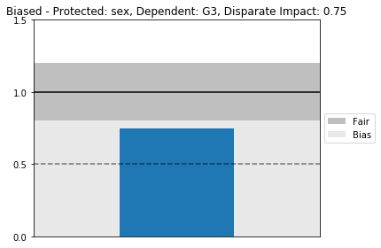

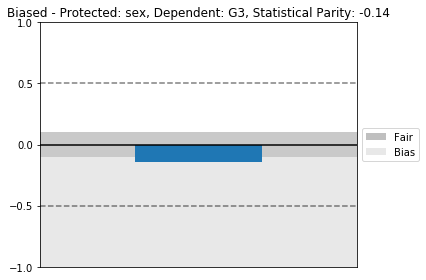

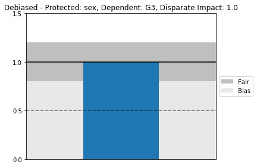

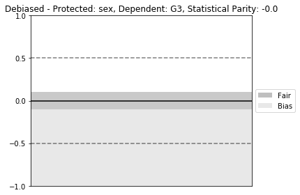

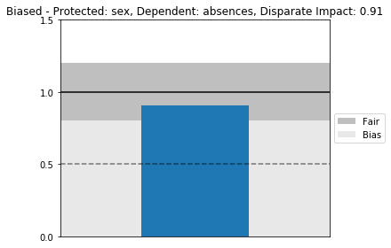

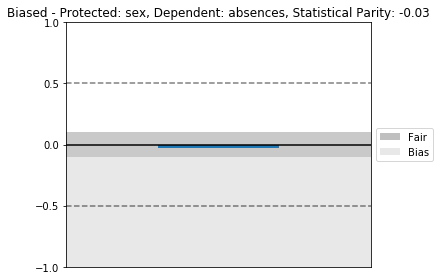

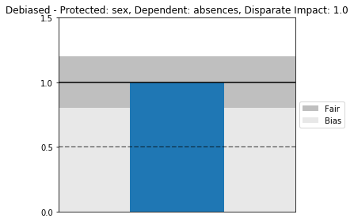

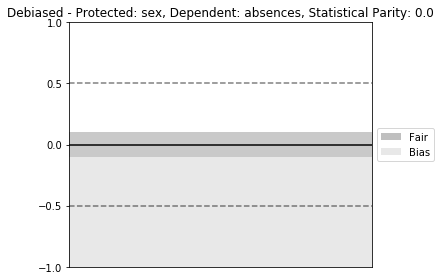

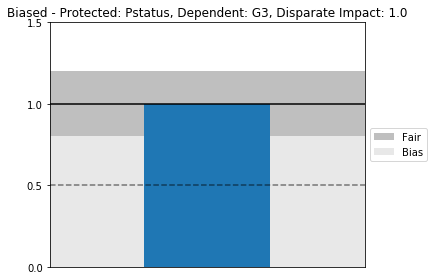

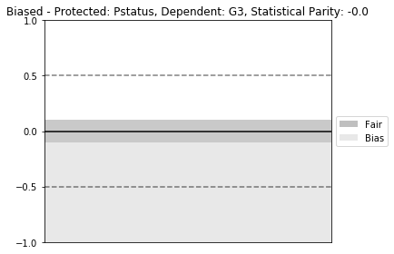

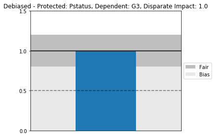

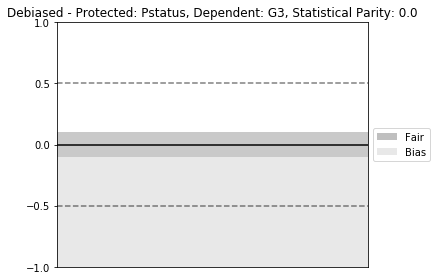

[12 more figures not shown]

```python
proclsvars = ['sex', 'Pstatus', 'age']
depenvars = ['G3', 'absences']

for proclsvar in proclsvars:
    for depenvar in depenvars:
        privileged_groups = [{proclsvar: 1}]
        unprivileged_groups = [{proclsvar: 0}]
        favorable_label = 0
        unfavorable_label = 1
        dataset = BinaryLabelDataset(favorable_label=favorable_label,
                                unfavorable_label=unfavorable_label,
                                df=df,
                                label_names=[depenvar],
                                protected_attribute_names=[proclsvar],
                                unprivileged_protected_attributes=unprivileged_groups)
        print("Dependent Variable", depenvar)
        print("Favorable label", dataset.favorable_label)
        print("Unfavorable label", dataset.unfavorable_label)
        print("Protected attribute", dataset.protected_attribute_names)
        if proclsvar == 'sex':
            print("Privileged protected attribute (1:Male and 0:Female)", dataset.privileged_protected_attributes)
            print("Unprivileged protected attribute (1:Male and 0:Female)", dataset.unprivileged_protected_attributes)
        elif proclsvar == 'Pstatus':
            print("Privileged protected attribute (1:Together and 0:Apart)", dataset.privileged_protected_attributes)
            print("Unprivileged protected attribute (1:Together and 0:Apart)", dataset.unprivileged_protected_attributes)
        elif proclsvar == 'age':
            print("Privileged protected attribute (1:Adult and 0:Teen)", dataset.privileged_protected_attributes)
            print("Unprivileged protected attribute (1:Adult and 0:Teen)", dataset.unprivileged_protected_attributes)

        metrics = BinaryLabelDatasetMetric(dataset,
                             unprivileged_groups=unprivileged_groups,
                             privileged_groups=privileged_groups)
        print("Statistical Parity Difference between unprivileged and privileged groups = %f" % metrics.statistical_parity_difference())
        print("Disparate Impact between unprivileged and privileged groups = %f" % metrics.disparate_impact())
        plot_DI('Biased' ,proclsvar, depenvar, round(metrics.disparate_impact(), 2))
        plot_SPD('Biased', proclsvar, depenvar, round(metrics.statistical_parity_difference(), 2))

        RW = Reweighing(unprivileged_groups=unprivileged_groups,
               privileged_groups=privileged_groups)
        RW.fit(dataset)
        debaisedRWds = RW.transform(dataset)

        debaisedRWmetric = BinaryLabelDatasetMetric(debaisedRWds,
                                             unprivileged_groups=unprivileged_groups,
                                             privileged_groups=privileged_groups)

        print("After Reweighing")
        print("Statistical Parity Difference between unprivileged and privileged groups = %f" % debaisedRWmetric.statistical_parity_difference())
        print("Disparate Impact between unprivileged and privileged groups = %f" % debaisedRWmetric.disparate_impact())
        plot_DI('Debiased', proclsvar, depenvar, round(debaisedRWmetric.disparate_impact(),2))
        plot_SPD('Debiased', proclsvar, depenvar, round(debaisedRWmetric.statistical_parity_difference(),2))
        print("------------------------------------------------")
```

### 4 Classification Algorithm on the Original and Debiased Datasets

Comparing the results and fairness metrics of logistics regression algorithm on the both original dataset and debiased dataset.

```python
#setting target variable as G3
features = ['school', 'sex', 'age', 'address', 'famsize', 'Pstatus', 'Medu', 'Fedu',
       'Mjob', 'Fjob', 'reason', 'guardian', 'traveltime', 'studytime',
       'failures', 'schoolsup', 'famsup', 'paid', 'activities', 'nursery',
       'higher', 'internet', 'romantic', 'famrel', 'freetime', 'goout', 'Dalc',
       'Walc', 'health']
labels = ['G3']
```

#### 4.1 Original Dataset

```python
# Get the dataset and split into train and test
dataset_orig_train, dataset_orig_vt = dataset.split([0.7], shuffle=True)
dataset_orig_valid, dataset_orig_test = dataset_orig_vt.split([0.5], shuffle=True)

# Logistic regression classifier and predictions
scale_orig = StandardScaler()
X_train = scale_orig.fit_transform(dataset_orig_train.features)
y_train = dataset_orig_train.labels.ravel()
w_train = dataset_orig_train.instance_weights.ravel()

lmod = LogisticRegression()
lmod.fit(X_train, y_train,
         sample_weight=dataset_orig_train.instance_weights)
y_train_pred = lmod.predict(X_train)

# positive class index
pos_ind = np.where(lmod.classes_ == dataset_orig_train.favorable_label)[0][0]

dataset_orig_train_pred = dataset_orig_train.copy()
dataset_orig_train_pred.labels = y_train_pred

dataset_orig_valid_pred = dataset_orig_valid.copy(deepcopy=True)
X_valid = scale_orig.transform(dataset_orig_valid_pred.features)
y_valid = dataset_orig_valid_pred.labels
dataset_orig_valid_pred.scores = lmod.predict_proba(X_valid)[:,pos_ind].reshape(-1,1)

dataset_orig_test_pred = dataset_orig_test.copy(deepcopy=True)
X_test = scale_orig.transform(dataset_orig_test_pred.features)
y_test = dataset_orig_test_pred.labels
dataset_orig_test_pred.scores = lmod.predict_proba(X_test)[:,pos_ind].reshape(-1,1)

num_thresh = 100
ba_arr = np.zeros(num_thresh)
class_thresh_arr = np.linspace(0.01, 0.99, num_thresh)
for idx, class_thresh in enumerate(class_thresh_arr):

    fav_inds = dataset_orig_valid_pred.scores > class_thresh
    dataset_orig_valid_pred.labels[fav_inds] = dataset_orig_valid_pred.favorable_label
    dataset_orig_valid_pred.labels[~fav_inds] = dataset_orig_valid_pred.unfavorable_label

    classified_metric_orig_valid = ClassificationMetric(dataset_orig_valid,
                                             dataset_orig_valid_pred,
                                             unprivileged_groups=unprivileged_groups,
                                             privileged_groups=privileged_groups)

    ba_arr[idx] = 0.5*(classified_metric_orig_valid.true_positive_rate()\
                       +classified_metric_orig_valid.true_negative_rate())

best_ind = np.where(ba_arr == np.max(ba_arr))[0][0]
best_class_thresh = class_thresh_arr[best_ind]

print("Best balanced accuracy (no reweighing) = %.4f" % np.max(ba_arr))
print("Optimal classification threshold (no reweighing) = %.4f" % best_class_thresh)
```

```
Best balanced accuracy (no reweighing) = 0.5542
Optimal classification threshold (no reweighing) = 0.2476
```

Predictions from original testing data

```
Classification threshold used = 0.2476
Balanced accuracy = 0.6802
Statistical parity difference = -0.3786
Disparate impact = 0.4952
Average odds difference = -0.3174
Equal opportunity difference = -0.2841
Theil index = 0.1315
```

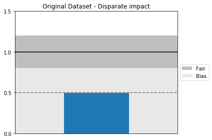

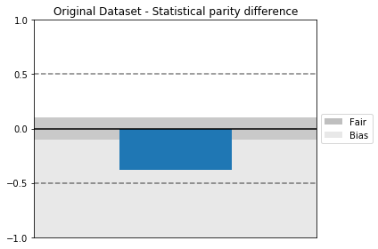

```python
display(Markdown("#### Predictions from original testing data"))
bal_acc_arr_orig = []
disp_imp_arr_orig = []
avg_odds_diff_arr_orig = []

print("Classification threshold used = %.4f" % best_class_thresh)
for thresh in tqdm(class_thresh_arr):

    if thresh == best_class_thresh:
        disp = True
    else:
        disp = False

    fav_inds = dataset_orig_test_pred.scores > thresh
    dataset_orig_test_pred.labels[fav_inds] = dataset_orig_test_pred.favorable_label
    dataset_orig_test_pred.labels[~fav_inds] = dataset_orig_test_pred.unfavorable_label

    metric_test_bef = compute_metrics(dataset_orig_test, dataset_orig_test_pred,
                                      unprivileged_groups, privileged_groups,
                                      disp = disp)

    bal_acc_arr_orig.append(metric_test_bef["Balanced accuracy"])
    avg_odds_diff_arr_orig.append(metric_test_bef["Average odds difference"])
    disp_imp_arr_orig.append(metric_test_bef["Disparate impact"])

    if disp == True:
        #Plot Disparate Impact - Original Dataset
        fig, axs = plt.subplots();
        plt.bar([0,1,2], [0, metric_test_bef.get('Disparate impact'),0])
        plt.axhline(y=1, color='black')
        plt.axhline(y=0.5, linestyle='dashed', color='black', alpha=0.5)
        plt.plot(0)
        plt.ylim(0,1.5)
        plt.xlim(0,2)
        plt.axhspan(0.8, 1.2, facecolor='grey', alpha=0.5, zorder=-100, label="Fair")
        plt.axhspan(0, 0.8, facecolor='lightgrey', alpha=0.5, zorder=-100, label="Bias")
        plt.xticks([])
        plt.yticks([0, 0.5, 1.0, 1.5])
        plt.title("Original Dataset - Disparate impact")
        plt.legend(loc='center left', bbox_to_anchor=(1, 0.5))
        fig.tight_layout()

        #Plot Statistical Parity Difference - Original Dataset
        fig, axs = plt.subplots();
        plt.bar([0,1,2], [0, metric_test_bef.get('Statistical parity difference'), 0])
        plt.axhline(y=0, color='black')
        plt.axhline(y=0.5, linestyle='dashed', color='black', alpha=0.5)
        plt.axhline(y=-0.5, linestyle='dashed', color='black', alpha=0.5)
        plt.plot(0)
        plt.ylim(-1,1)
        plt.xlim(0,2)
        plt.axhspan(-0.1, 0.1, facecolor='grey', alpha=0.5, zorder=-100, label="Fair")
        plt.axhspan(0.1, -1, facecolor='lightgrey', alpha=0.5, zorder=-100, label="Bias")
        plt.xticks([])
        plt.yticks([-1, -0.5, 0, 0.5, 1.0])
        plt.title("Original Dataset - Statistical parity difference")
        plt.legend(loc='center left', bbox_to_anchor=(1, 0.5))
        fig.tight_layout()
```

#### 4.2 Debaised Dataset

```python
# Get the dataset and split into train and test
dataset_dbias_train, dataset_dbias_vt = debaisedRWds.split([0.7], shuffle=True)
dataset_dbias_valid, dataset_dbias_test = debaisedRWds.split([0.5], shuffle=True)

# Logistic regression classifier and predictions
scale_dbias = StandardScaler()
X_train = scale_dbias.fit_transform(dataset_dbias_train.features)
y_train = dataset_dbias_train.labels.ravel()
w_train = dataset_dbias_train.instance_weights.ravel()

lmod = LogisticRegression()
lmod.fit(X_train, y_train,
         sample_weight=dataset_dbias_train.instance_weights)
y_train_pred = lmod.predict(X_train)

# positive class index
pos_ind = np.where(lmod.classes_ == dataset_dbias_train.favorable_label)[0][0]

dataset_dbias_train_pred = dataset_dbias_train.copy()
dataset_dbias_train_pred.labels = y_train_pred

dataset_dbias_valid_pred = dataset_dbias_valid.copy(deepcopy=True)
X_valid = scale_dbias.transform(dataset_dbias_valid_pred.features)
y_valid = dataset_dbias_valid_pred.labels
dataset_dbias_valid_pred.scores = lmod.predict_proba(X_valid)[:,pos_ind].reshape(-1,1)

dataset_dbias_test_pred = dataset_dbias_test.copy(deepcopy=True)
X_test = scale_dbias.transform(dataset_dbias_test_pred.features)
y_test = dataset_dbias_test_pred.labels
dataset_dbias_test_pred.scores = lmod.predict_proba(X_test)[:,pos_ind].reshape(-1,1)

num_thresh = 100
ba_arr = np.zeros(num_thresh)
class_thresh_arr = np.linspace(0.01, 0.99, num_thresh)
for idx, class_thresh in enumerate(class_thresh_arr):

    fav_inds = dataset_dbias_valid_pred.scores > class_thresh
    dataset_dbias_valid_pred.labels[fav_inds] = dataset_dbias_valid_pred.favorable_label
    dataset_dbias_valid_pred.labels[~fav_inds] = dataset_dbias_valid_pred.unfavorable_label

    classified_metric_dbias_valid = ClassificationMetric(dataset_dbias_valid,
                                             dataset_dbias_valid_pred,
                                             unprivileged_groups=unprivileged_groups,
                                             privileged_groups=privileged_groups)

    ba_arr[idx] = 0.5*(classified_metric_dbias_valid.true_positive_rate()\
                       +classified_metric_dbias_valid.true_negative_rate())

best_ind = np.where(ba_arr == np.max(ba_arr))[0][0]
best_class_thresh = class_thresh_arr[best_ind]

print("Best balanced accuracy (reweighing) = %.4f" % np.max(ba_arr))
print("Optimal classification threshold (reweighing) = %.4f" % best_class_thresh)
```

```
Best balanced accuracy (reweighing) = 0.7116
Optimal classification threshold (reweighing) = 0.3268
```

Predictions from original testing data

```
Classification threshold used = 0.3268
Balanced accuracy = 0.6294
Statistical parity difference = -0.0208
Disparate impact = 0.9496
Average odds difference = -0.0439
Equal opportunity difference = -0.0745
Theil index = 0.1893
```

```
  return metric_fun(privileged=False) / metric_fun(privileged=True)
```

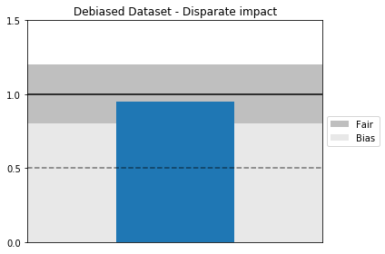

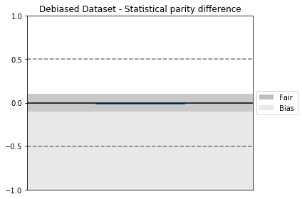

```python
display(Markdown("#### Predictions from original testing data"))
bal_acc_arr_dbias = []
disp_imp_arr_dbias = []
avg_odds_diff_arr_dbias = []

print("Classification threshold used = %.4f" % best_class_thresh)
for thresh in tqdm(class_thresh_arr):

    if thresh == best_class_thresh:
        disp = True
    else:
        disp = False

    fav_inds = dataset_dbias_test_pred.scores > thresh
    dataset_dbias_test_pred.labels[fav_inds] = dataset_dbias_test_pred.favorable_label
    dataset_dbias_test_pred.labels[~fav_inds] = dataset_dbias_test_pred.unfavorable_label

    metric_test_aft = compute_metrics(dataset_dbias_test, dataset_dbias_test_pred,
                                      unprivileged_groups, privileged_groups,
                                      disp = disp)

    bal_acc_arr_dbias.append(metric_test_aft["Balanced accuracy"])
    avg_odds_diff_arr_dbias.append(metric_test_aft["Average odds difference"])
    disp_imp_arr_dbias.append(metric_test_aft["Disparate impact"])

    if disp == True:
        #Plot Disparate Impact - Original Dataset
        fig, axs = plt.subplots();
        plt.bar([0,1,2], [0, metric_test_aft.get('Disparate impact'),0])
        plt.axhline(y=1, color='black')
        plt.axhline(y=0.5, linestyle='dashed', color='black', alpha=0.5)
        plt.plot(0)
        plt.ylim(0,1.5)
        plt.xlim(0,2)
        plt.axhspan(0.8, 1.2, facecolor='grey', alpha=0.5, zorder=-100, label="Fair")
        plt.axhspan(0, 0.8, facecolor='lightgrey', alpha=0.5, zorder=-100, label="Bias")
        plt.xticks([])
        plt.yticks([0, 0.5, 1.0, 1.5])
        plt.title("Debiased Dataset - Disparate impact")
        plt.legend(loc='center left', bbox_to_anchor=(1, 0.5))
        fig.tight_layout()

        #Plot Statistical Parity Difference - Original Dataset
        fig, axs = plt.subplots();
        plt.bar([0,1,2], [0, metric_test_aft.get('Statistical parity difference'), 0])
        plt.axhline(y=0, color='black')
        plt.axhline(y=0.5, linestyle='dashed', color='black', alpha=0.5)
        plt.axhline(y=-0.5, linestyle='dashed', color='black', alpha=0.5)
        plt.plot(0)
        plt.ylim(-1,1)
        plt.xlim(0,2)
        plt.axhspan(-0.1, 0.1, facecolor='grey', alpha=0.5, zorder=-100, label="Fair")
        plt.axhspan(0.1, -1, facecolor='lightgrey', alpha=0.5, zorder=-100, label="Bias")
        plt.xticks([])
        plt.yticks([-1, -0.5, 0, 0.5, 1.0])
        plt.title("Debiased Dataset - Statistical parity difference")
        plt.legend(loc='center left', bbox_to_anchor=(1, 0.5))
        fig.tight_layout()
```

#### Attributions

[1] Zemel et al. ICML2013, Louizos et al. ICLR2016, Lum and Johndrow 2016, Adler et al. 2016, Calmon et al. NIPS2017, Barrio et al. 2018 [2] P. Cortez and A. Silva. Using Data Mining to Predict Secondary School Student Performance. In A. Brito and J. Teixeira Eds., Proceedings of 5th FUture BUsiness TEChnology Conference (FUBUTEC 2008) pp. 5-12, Porto, Portugal, April, 2008, EUROSIS, ISBN 978-9077381-39-7. [Web Link]